# Análisis Numérico - Sandra Chavez, Santiago Romero y Ricardo Bernal

```r
itersolve(A, b, nmax = 5, tol = 1e-9, method = "Jacobi")
```

```
## Iteraci?n  1  -> Error relativo =  1.98532
## Iteraci?n  2  -> Error relativo =  2.504266
## Iteraci?n  3  -> Error relativo =  6.068028
## Iteraci?n  4  -> Error relativo =  6.354898
## Iteraci?n  5  -> Error relativo =  13.31229
##
## N?mero de iteraciones realizado fue  5
##
## Soluciones:[1]  -1.948478  -1.428082  -2.974085 -37.941560
```

```r
#Referencias
#rstudio-pubs-static.s3.amazonaws.com
```

3. Sea el sistema $AX=b$ dados en ejercicio,y con tol= e^-8
1. Implemente una función en R para que evalue las raíces del polinomio característico asociado a la matriz $A$
2. Use el teorema de convergencia para determinar cuál método iterativo es más favorable.
3. Evalue la matriz de transición para cada caso (método) y en el caso del método de relajación determine el valor óptimo de $\omega$
4. Teniendo en cuenta lo anterior resolver el sistema  
   e Comparar con la solución por defecto
5. Evaluar el número de condición de la matriz A
6. Evaluar el efecto en la solución si la entradad $a_{11}=4.01$ aplicar cambio y solucionar. Después, debe comparar con el valor condicón.

```r
A = matrix(c(4, -1, -1, -1, -1, 4,
-1, -1, -1, -1, 4, -1,
-1, -1, -1, 4), nrow=4, byrow=TRUE)
A
```

```
##      [,1] [,2] [,3] [,4]
## [1,]    4   -1   -1   -1
## [2,]   -1    4   -1   -1
## [3,]   -1   -1    4   -1
## [4,]   -1   -1   -1    4
```

```r
b = c(1.11111, 5, 1.5,-2.33)
b
```

```
## [1]  1.11111  5.00000  1.50000 -2.33000
```

-> Hecho - Revisar Ejercicio3.R

````r
#Ejercicio 3
#
#
#3. Sea el sistema $AX=b$ dados en ejercicio,y  con tol= e^-8
#a. Implemente una funciÃ³n en R para que evalue las raÃces del polinomio caracterÃstico asociado a la matriz $A$
#  b. Use el teorema de convergencia para determinar cuÃ¡l mÃ©todo iterativo es mÃ¡s favorable.
#c. Evalue la matriz de transiciÃ³n para cada caso (mÃ©todo) y en el caso del mÃ©todo de relajaciÃ³n determine el valor Ã³ptimo de $\omega$
#  d. Teniendo en cuenta lo anterior resolver el sistema
#e Comparar con la soluciÃ³n por defecto
#f. Evaluar el nÃºmero de condiciÃ³n de la matriz A
#g. Evaluar el efecto en la soluciÃ³n si la entradad $a_{11}=4.01$ aplicar cambio y solucionar. DespuÃ©s, debe comparar con el valor condicÃ³n

#```{r, echo=T}
#A = matrix(c(4, -1, -1, -1, -1, 4,
#             -1, -1, -1, -1, 4, -1,
#             -1, -1, -1, 4), nrow=4, byrow=TRUE)
#A
#b = c(1.11111, 5, 1.5,-2.33)
#b
#```
rm(list=ls())
library(pracma)
library(Matrix)

#Punto A
A = matrix(c(4, -1, -1, -1, -1, 4,
             -1, -1, -1, -1, 4, -1,
             -1, -1, -1, 4), nrow=4, byrow=TRUE)
print(A)
````

```
##      [,1] [,2] [,3] [,4]
## [1,]    4   -1   -1   -1
## [2,]   -1    4   -1   -1
## [3,]   -1   -1    4   -1
## [4,]   -1   -1   -1    4
```

```r
b = c(1.11111, 5, 1.5,-2.33)
print(b)
```

```
## [1]  1.11111  5.00000  1.50000 -2.33000
```

```r
qr.solve(A,b)
```

```
## [1] 1.278444 2.056222 1.356222 0.590222
```

```r
#punto B





# Parte B


# Matriz A
#Punto A
A = matrix(c(4, -1, -1, -1, -1, 4,
             -1, -1, -1, -1, 4, -1,
             -1, -1, -1, 4), nrow=4, byrow=TRUE)
print(A)
```

```
##      [,1] [,2] [,3] [,4]
## [1,]    4   -1   -1   -1
## [2,]   -1    4   -1   -1
## [3,]   -1   -1    4   -1
## [4,]   -1   -1   -1    4
```

```r
b = c(1.11111, 5, 1.5,-2.33)
print(b)
```

```
## [1]  1.11111  5.00000  1.50000 -2.33000
```

```r
# Ahora vamos a evaluar la solucion con cada uno de los metodos iterativos y determinaremos cual es mas favorable
# Teniendo en cuenta que ambos son algoritmos lineales entonces tienen una complejidad de O(n)

toleracia=1e-9
# Por Gauss-Seidel

solGS=itersolve(A,b,x0=NULL,nmax = 1000,toleracia,method = "Gauss-Seidel")
print(solGS)
```

```
## $x
## [1] 1.278444 2.056222 1.356222 0.590222
##
## $iter
## [1] 36
##
## $method
## [1] "Gauss-Seidel"
```

```r
# Por Jacobi

solJacobi=itersolve(A, b, 1:4,nmax = 1000, toleracia, method = c("Jacobi"))
print(solJacobi)
```

```
## $x
## [1] 1.278444 2.056222 1.356222 0.590222
##
## $iter
## [1] 66
##
## $method
## [1] "Jacobi"
```

```r
# Por Richardson
solRichar=itersolve(A, b, x0 = NULL, nmax = 1000, toleracia, method = c("Richardson"))
print(solRichar)
```

```
## $x
## [1] 1.278444 2.056222 1.356222 0.590222
##
## $iter
## [1] 39
##
## $method
## [1] "Richardson"
```

```r
print("Como se puede observar por la cantidad de iteraciones el metodo de gauss-sediel es mas rapido\nlo que quiere decir que converge mas rapido que los algoritmos jacobi y richardson ")
```

```
## [1] "Como se puede observar por la cantidad de iteraciones el metodo de gauss-sediel es mas rapido\nlo que quiere decir que converge mas rapido que los algoritmos jacobi y richardson "
```

```r
#Punto c

A = matrix(c(4, -1, -1, -1, -1, 4,
             -1, -1, -1, -1, 4, -1,
             -1, -1, -1, 4), nrow=4, byrow=TRUE)
print(A)
```

```
##      [,1] [,2] [,3] [,4]
## [1,]    4   -1   -1   -1
## [2,]   -1    4   -1   -1
## [3,]   -1   -1    4   -1
## [4,]   -1   -1   -1    4
```

```r
b = c(1.11111, 5, 1.5,-2.33)
print(b)
```

```
## [1]  1.11111  5.00000  1.50000 -2.33000
```

```r
# w grado de relajaciÃ³n 0<w<2
fSOR<-function(a,n,w){
  D=a*eye(n, m = n)
  L<-a
  L[lower.tri(L, diag = FALSE)]<-0
  auxT=(D-(w*L))
  auxT1=inv(auxT)
  U<-a
  U[upper.tri(U, diag = FALSE)]<-0
  auxT2=((1-w)*D+(w*U))
  Tfinal=auxT1*auxT2
}
#fSOR(A,4,1)
#Jacobi
#se realiza la separacion de jacobi entre D, L, U y el resultado es la sumatoria de todas estas divisiones.
jacobi<-function(a,n){
  D=a*eye(n, m = n)
  L<-a
  L[lower.tri(L, diag = FALSE)]<-0
  U<-a
  U[upper.tri(U, diag = FALSE)]<-0
  AA=D+L+U
  print(AA)
}
jacobi(A,4) # Punto D
```

```
##      [,1] [,2] [,3] [,4]
## [1,]   12   -1   -1   -1
## [2,]   -1   12   -1   -1
## [3,]   -1   -1   12   -1
## [4,]   -1   -1   -1   12
```

```r
#Punto E
solucion<- solve(A,b)
print(solucion)
```

```
## [1] 1.278444 2.056222 1.356222 0.590222
```

4. 1. Pruebe el siguiente algoritmo con una matriz $A_{6}$, modifiquelo para que $a_{ii}=0$ para todo $i$

```r
tril1 <- function(M, k = 0) {
if (k == 0) {
M[upper.tri(M, diag = FALSE)] <- 0
} else {
M[col(M) >= row(M) + k + 1] <- 0
}
return(M)
}
```

->Hecho. Revisar Ejericio4.R

```r
#Ejercicio 4

#4. Pruebe el siguiente algoritmo con una matriz $A_{3}$, modifiquelo para quue $a_{ii}=0$ para todo $i$

tril1 <- function(M, k)
{
  if (k != 0) {
    M[!lower.tri(M, diag = TRUE)] <- 0
    M[!upper.tri(M, diag = TRUE)] <- 0
  }
  else {
    M[col(M) == row(M) + k ] <- 0
  }
  return(M)
}
M = matrix(c(9,7,4,
             10,9,5,
             6,8,7,
             2,1,4), nrow = 4, byrow = TRUE)
r<- tril1(M, 0)
print("Resultado de la funcion:")
```

```
## [1] "Resultado de la funcion:"
```

```r
print(r)
```

```
##      [,1] [,2] [,3]
## [1,]    0    7    4
## [2,]   10    0    5
## [3,]    6    8    0
## [4,]    2    1    4
```

5. Cree una función que cuente el número de multiplicaciones en el método directo de Gauss-Jordan, para resolver un sistema de $n$ ecuaciones y pruebelo para $n=5$

-> Hecho. Revisar Ejercicio5.R

```r
# Ejercicio 5

#5. Cree una función que cuente el número de multiplicaciones
#en el método directo de Gauss-Jordan, para resolver
#un sistema de $n$ ecuaciones y pruebelo para $n=5$


GaussJordanM = function(A, B){ # Se supone det(A) != 0
  numMult = 0
  n = nrow(A) # = ncol(A) para que sea cuadrada

  # matriz ampliada
  Ab = cbind(A,B)
  print(Ab)
  # Eliminación
  for (k in 1:(n-1)){ # desde columna k=1 hasta k=n-1
    if(Ab[k,k]==0){ # intercambio de fila
      fila = which(Ab[k, ]!=0)[1]
      Ab[c(k, fila), ] = Ab[c(fila, k), ]
    }

    # Eliminación columna k
    for (i in (k+1):n){# debajo de la diagonal
      # Fi = Fi - a_ik/a_kk * Fk, i=k+1,...,n
      Ab[i, ] = Ab[i, ] - Ab[i, k]/Ab[k,k]*Ab[k, ]
      numMult = numMult + 2*(ncol(Ab))
    }
  }

  # Sustitución hacia atrás-------------------------
  x = rep(NA, times=n)
  x[n] = Ab[n, n+1]/Ab[n,n]
  numMult = numMult + n+1

  for(i in (n-1):1 )
    {
    x[i]= (Ab[i, n+1] - sum(Ab[i, (i+1):n]*x[(i+1):n]) ) /Ab[i,i]
    numMult = numMult + 2*(n-2)
    }

  cat("Numero de Multiplicaciones del ejercicio:", numMult, "\n")
  return(x)
}

A = matrix(c( 0, 1,1,1,1,
              -5, -4, 3, 4, 8,
              0, 7, -2, 3, 7,
              -1, -7, -8, 3,7,
              3, 7, 5, 5, 9), nrow=5, byrow=TRUE)
B = matrix(c(1,0,0,0,1), nrow=5, byrow=TRUE)

cat("Solucion ejercicio Punto  5: ","\n")
```

```
## Solucion ejercicio Punto  5:
```

```r
GaussJordanM(A,B)
```

```
##      [,1] [,2] [,3] [,4] [,5] [,6]
## [1,]    0    1    1    1    1    1
## [2,]   -5   -4    3    4    8    0
## [3,]    0    7   -2    3    7    0
## [4,]   -1   -7   -8    3    7    0
## [5,]    3    7    5    5    9    1
## Numero de Multiplicaciones del ejercicio: 150
```

```
## [1] -0.06199461  0.06334232 -0.13746631  2.05929919 -0.98517520
```

7. Dado el siguiente sistema:

$2x-z=1$ $\beta$$x+2y-z=2$ $-x+y+ \alpha$$z=1$

1. Encuentre el valor de $\alpha$ y $\beta$ para asegura la convergencia por el método de Jacobi y para Gauss Seidel. Sugerencia: utilice el teorema convergencia
2. Genere una tabla que tenga 10 iteraciones, del método de Jacobi con vector inicial $x_{0}=[1,2,3]^t$

-> Hecho - Revisar Ejercicio3.R

```r
# Ejercicio 7
# Parte A - Encuentre los valores de Alpha y Beta de la matriz A para asegurar la convergencia de Jacobi
# Convergencia de Jacobi -> A debe ser 'estrictamente diagonal dominante'

require(BB)
require(Matrix)
require(pracma)

beta  <- 0
alpha <- 3

A = matrix(c( 2,0,-1,
              beta,2,-1,
              -1,1,alpha),nrow=3,byrow=TRUE)
print(A)
```

```
##      [,1] [,2] [,3]
## [1,]    2    0   -1
## [2,]    0    2   -1
## [3,]   -1    1    3
```

```r
b = matrix (c(1,2,1),nrow=3, byrow=TRUE)
Ab = cbind(A,b)
print(Ab) # Aca se puede verificar de forma visual la condicion de convergencia.
```

```
##      [,1] [,2] [,3] [,4]
## [1,]    2    0   -1    1
## [2,]    0    2   -1    2
## [3,]   -1    1    3    1
```

```r
sol1 = solve(A,b) # Reemplazar solve por Jacobi!!!!
print(sol1)
```

```
##           [,1]
## [1,] 0.5833333
## [2,] 1.0833333
## [3,] 0.1666667
```

```r
# Parte B - Genere una tabla que tenga 10 iteraciones

toleracia=1e-9

solJacobi=itersolve(A, b, x0 = c(1,2,3), nmax = 10, toleracia, method = c("Jacobi"))
print(solJacobi)
```

[output not shown]

8. Instalar el paquete Matrix y descomponga la matriz $A$ (del punto dos) de la forma $LU$ y la factorizarla como $A=QR$. Verifique su respuesta.

-> Hecho - Revisar Ejercicio8.R

```r
#Ejercicio 8

#NOTA: Se debe instalar pracma y Matrix para calcular las triangulares inferiores y superiores

require(pracma)
require(Matrix)

n = 4 # Matriz con dimensiones 4x4

D1<-eye(n, m = n)
D2<-ones(n, m = n)
D3<-zeros(n, m = n)

# Matriz A del ejercicio 2

A = matrix(c(-8.1, -7/4, 6.1, -2,
             -1, 4, -3, -1,
             0, -1, -5, 0.6,
             -1, 1/3, 6, 1/2), nrow=4, byrow=TRUE)
print(A)
```

```
##      [,1]       [,2] [,3] [,4]
## [1,] -8.1 -1.7500000  6.1 -2.0
## [2,] -1.0  4.0000000 -3.0 -1.0
## [3,]  0.0 -1.0000000 -5.0  0.6
## [4,] -1.0  0.3333333  6.0  0.5
```

```r
# Descomposicion de matriz A en A=LU

ludec <- lu(A)
LU_Desc <- expand(ludec)

L <- LU_Desc$L # L = Matriz triangular inferior
print(L)
```

```
## 4 x 4 Matrix of class "dtrMatrix" (unitriangular)
##      [,1]       [,2]       [,3]       [,4]
## [1,]  1.0000000          .          .          .
## [2,]  0.1234568  1.0000000          .          .
## [3,]  0.0000000 -0.2371889  1.0000000          .
## [4,]  0.1234568  0.1303075 -0.9738172  1.0000000
```

```r
U <- LU_Desc$U # U = Matriz triangular superior
print(U)
```

```
## 4 x 4 Matrix of class "dtrMatrix"
##      [,1]       [,2]       [,3]       [,4]
## [1,] -8.1000000 -1.7500000  6.1000000 -2.0000000
## [2,]          .  4.2160494 -3.7530864 -0.7530864
## [3,]          .          . -5.8901903  0.4213763
## [4,]          .          .          .  1.2553898
```

```r
#D <- diag(diag(A))
#print(D)

A1 = L %*% U # Multiplicamos para verificar
print(A1)
```

```
## 4 x 4 Matrix of class "dgeMatrix"
##      [,1]       [,2] [,3] [,4]
## [1,] -8.1 -1.7500000  6.1 -2.0
## [2,] -1.0  4.0000000 -3.0 -1.0
## [3,]  0.0 -1.0000000 -5.0  0.6
## [4,] -1.0  0.3333333  6.0  0.5
```

```r
# Factorizacion de matriz A en A=QR
# Q = Matriz ortogonal (Q^T * Q = I)
# R -> U = Matriz triangular superior
# Estas matrices se obtienen por medio de Gram-Schimidt

QR <- gramSchmidt(A)
print(QR)
```

```
## $Q
##            [,1]       [,2]        [,3]        [,4]
## [1,] -0.9850983 -0.1318803 -0.05337425 -0.09664471
## [2,] -0.1216171  0.9576070 -0.25114074  0.07159958
## [3,]  0.0000000 -0.2309955 -0.68333394  0.69260075
## [4,] -0.1216171  0.1106234  0.68347220  0.71122254
##
## $R
##         [,1]     [,2]      [,3]       [,4]
## [1,] 8.22253 1.196915 -6.373951  2.0310050
## [2,] 0.00000 4.329088 -1.858573 -0.7771320
## [3,] 0.00000 0.000000  7.945342  0.2896250
## [4,] 0.00000 0.000000  0.000000  0.8928615
```

```r
Q <- QR$Q
print(Q)
```

```
##            [,1]       [,2]        [,3]        [,4]
## [1,] -0.9850983 -0.1318803 -0.05337425 -0.09664471
## [2,] -0.1216171  0.9576070 -0.25114074  0.07159958
## [3,]  0.0000000 -0.2309955 -0.68333394  0.69260075
## [4,] -0.1216171  0.1106234  0.68347220  0.71122254
```

```r
R <- QR$R
print(R)
```

```
##         [,1]     [,2]      [,3]       [,4]
## [1,] 8.22253 1.196915 -6.373951  2.0310050
## [2,] 0.00000 4.329088 -1.858573 -0.7771320
## [3,] 0.00000 0.000000  7.945342  0.2896250
## [4,] 0.00000 0.000000  0.000000  0.8928615
```

```r
A2 = Q %*% R # Multiplicamos para verificar
print(A2)
```

```
##      [,1]       [,2] [,3] [,4]
## [1,] -8.1 -1.7500000  6.1 -2.0
## [2,] -1.0  4.0000000 -3.0 -1.0
## [3,]  0.0 -1.0000000 -5.0  0.6
## [4,] -1.0  0.3333333  6.0  0.5
```

9. Realice varias pruebas que la matriz de transición por el método de Gauss-Seidel esta dada por $T=(-D^{-1}U)(I+LD^{-1})^{-1}$

-> Hecho. Revisar Ejericio9.R y su demostracion en .pdf

```r
# Ejercicio 9

#9. Realice varias pruebas que la matriz de transición por
#el método de Gauss-Seidel esta dada por $T=(-D^{-1}U)(I+LD^{-1})^{-1}$

N <- 3
A <- Diag(rep(3,N)) + Diag(rep(-2, N-1), k=-1) + Diag(rep(-1, N-1), k=1)
x0 <- rep(0, N)
B = c(4,5,9)

itersolve(A, B, tol=1e-7 , method = "Gauss-Seidel")
```

```
## $x
## [1] 3.466666 6.400000 7.266666
##
## $iter
## [1] 21
##
## $method
## [1] "Gauss-Seidel"
```

### Sistemas No lineales

1. Determinar numéricamente la intersección entre la circunferencia $x^2 + y^2 = 1$ y la recta $y = x$. Usamos una aproximación inicial $(1,1)$.

-> Hecho - Revisar Ejercicio10A.R

```r
#Ejercicio 10 - Parte A
#NOTA: Se debe instalar lib BB

require(BB)

sistema = function(x){
  f = rep(NA,length(x))
  f[1] = x[1]^2+x[2]^2-1
  f[2] = x[1]-x[2]
  f
}

p0 = c(1,1)
sol1=BBsolve(par=p0, fn=sistema) # msg: Succesful convergence
```

```
##   Successful convergence.
```

```r
cat("Solucion inicial de (1,1): \n",sol1[[1]],"\n")
```

```
## Solucion inicial de (1,1):
##  0.7071068 0.7071068
```

```r
p0 = c(-1,1)
sol2=BBsolve(par=p0, fn=sistema) # msg: Succesful convergence
```

```
##   Successful convergence.
```

```r
cat("Solucion inicial de (-1,1): \n",sol2[[1]],"\n")
```

```
## Solucion inicial de (-1,1):
##  -0.7071068 -0.7071067
```

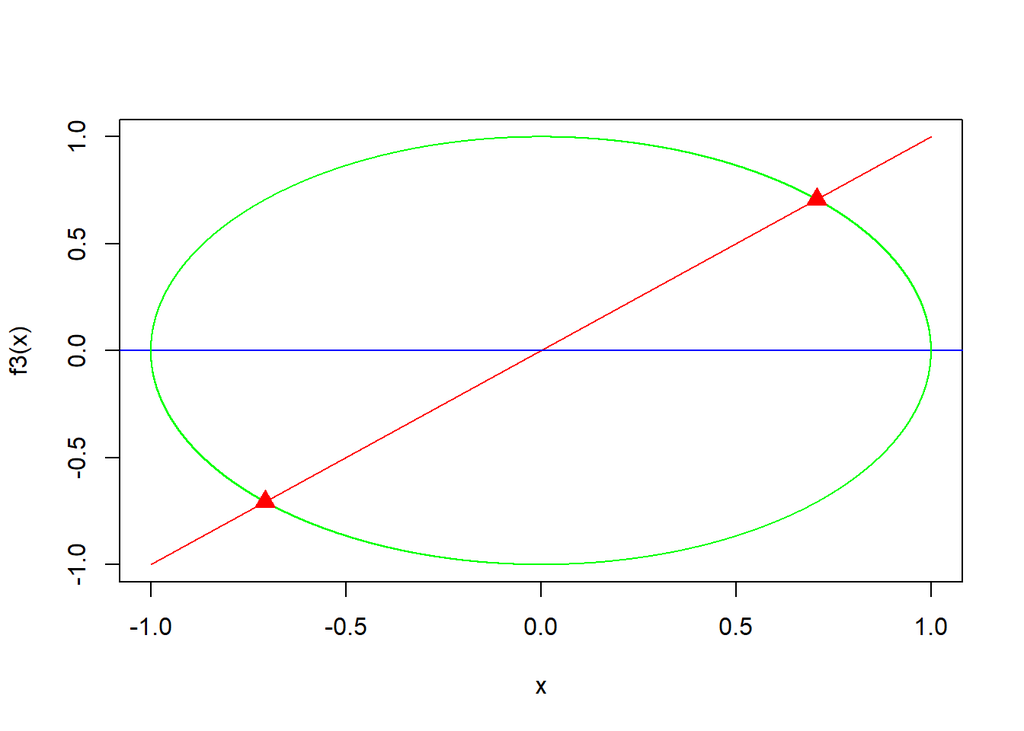

```r
# Las soluciones para x^2+y^2=1 son:
# y1 = sqrt(1-x^2); y2 = sqrt(1-x^2) -- Con Centro en (0,0)

f1=function(x){
  sqrt(1-x^2)
}
f2=function(x){
  -sqrt(1-x^2)
}
f3=function(x){
  x
}

# Al resover x^2 + y^2 = 1 respecto a la recta y=x, se obtienen
# los siguientes puntos:
#   x1=(1/sqrt(2)); x2=(-1/sqrt(2))
#   Al radicalizar +- (1/sqrt(2)), se obtiene (sqrt(2)/2)

x=seq(-1,1,0.00001) # Con una tolerancia de 10e-6
plot(x,f3(x),type="l",col="red")
abline(h=0,col="blue") # Eje X
lines(x,f1(x),type="l",col="green") # Circunferencia arriba del eje X
lines(x,f2(x),type="l",col="green") # Circunferencia por debajo del eje X
points(rbind(c(sqrt(2)/2,sqrt(2)/2)),pch=17,cex=1.5,col="red") # Puntos de Interseccion
points(rbind(c(-sqrt(2)/2,-sqrt(2)/2)),pch=17,cex=1.5,col="red") # Puntos de Interseccion
```

b Analizar y comentar el siguiente código

```r
trigexp = function(x) {
n = length(x)
F = rep(NA, n)
F[1] = 3*x[1]^2 + 2*x[2] - 5 + sin(x[1] - x[2]) * sin(x[1] + x[2])
tn1 = 2:(n-1)
F[tn1] = -x[tn1-1] * exp(x[tn1-1] - x[tn1]) + x[tn1] *
( 4 + 3*x[tn1]^2) + 2 * x[tn1 + 1] + sin(x[tn1] -
x[tn1 + 1]) * sin(x[tn1] + x[tn1 + 1]) - 8
F[n] = -x[n-1] * exp(x[n-1] - x[n]) + 4*x[n] - 3
F
}
n = 10000
p0 = runif(n) # n initial random starting guesses
sol = BBsolve(par=p0, fn=trigexp)
```

```
##   Successful convergence.
```

```r
sol$par
```

[output not shown]

[output cut: 1414 more lines]

-> Hecho - Revisar Ejercicio10B.R

```r
#Ejercicio 10 - Parte B

#NOTA: Se debe instalar lib BB

library("BB")
require(BB)

# Funcion 1: 3x^2+2y-5+sin(x-y)*sin(x+y)

trigexp = function(x) {
  n = length(x)
  F = rep(NA, n)

  # Ecuaciones del sistema
  F[1] = 3*x[1]^2 + 2*x[2] - 5 + sin(x[1] - x[2]) * sin(x[1] + x[2])

  tn1 = 2:(n-1) # Esto actua como un 'for in range(2,n-1)' = Secuencia de 2
                # hasta n-1 para los valores de X

  # Se establece el siguiente sistema de ecuciones:
  # se ingresan tn1 ecuaciones que iran desde 2 hasta n-1
  F[tn1] = -x[tn1-1] * exp(x[tn1-1] - x[tn1]) + x[tn1] *
    ( 4 + 3*x[tn1]^2) + 2 * x[tn1 + 1] + sin(x[tn1] -
                                               x[tn1 + 1]) * sin(x[tn1] + x[tn1 + 1]) - 8

  # Como la anterior evalua hasta n-1, aca se evalua la ecuacion para n
  F[n] = -x[n-1] * exp(x[n-1] - x[n]) + 4*x[n] - 3  # Esta ecuacion puede ser descrita como:
                                                    # -z * e^(z-w) + 4z - 3
  F # Retornamos
}

n = 10000 # Cantidad de numeros aleatorios para la ecuacion - Aca serian 10000 casos para evaluar la efectividad del metodo
p0 = runif(n) # Genera 'n' numeros aleatorios para los "valores iniciales" para F
sol = BBsolve(par=p0, fn=trigexp)
```

```
##   Successful convergence.
```

```r
sol$par # 10mil Soluciones
```

[output not shown]

[output cut: 1414 more lines]

```r
# [1] 1 1 1 1 1 .......
```